# Proyecto Final

Opt. Análisis de datos estadísticos en R

Bárbara Sepúlveda Castillo

22-11-2021

**Universidad Alberto Hurtado**

**Profesora: Valentina Andrade**

**Ayudantes: Dafne Jaime y Nicolás Godoy**

# Proyecto de investigación: “Factores que repercuten en la salud mental de los chilenos/as en pandemia por COVID-19”

# Abstract

La pandemia por COVID-19 ha afecta la vida de las personas en distintos ámbitos de sus vidas. Ha significado cambios radicales que nunca antes se habían experimentado. Las relaciones cambiaron, el confinamiento se aplicó en todo el mundo, y esto trajo consigo una serie de problemas en la salud mental de las personas por diferentes factores psicosociales según explican en las investigaciones. Este proyecto se centra en mostrar como algunos de ellos pueden afectar en la percepción del estado de ánimo de las personas y también caracterizarlo según el rango etario y sexo. Esto último, ya que las más importantes investigaciones han destacado el hecho de que los adultos mayores han sido los más afectados en salud mental debido al confinamiento, y así mismo las mujeres, quienes han tenido que hacerse cargo de la mayoría de las labores domésticas a la misma vez de sus labores económicas.

# Introducción

La pandemia de Covid-19 ha traído consigo diversos cambios en la vida de las personas, desde la compra de productos básicos hasta las formas de relacionarse y comunicarse. Este proyecto se interesa por abordar aquellos factores que pueden o no influir en la percepción del estado de ánimo actual que tienen los chilenos/as en pandemia. A partir de la encuesta Termómetro social realizada en octubre del 2020, se analizarán estos factores, que se definieron a partir de la i nvestigación de Buitrago et. al (2021) en donde indican que los factores psicosociales que afectan la salud mental pueden ser “autopercepción de mal estado de salud, frustración aburrimiento y soledad, sentimientos de privación de libertad, inexistencia o no utilización del factor protector del sentimiento de solidaridad y apoyo mutuo”, etc. (Buitrago et. al, 2021) Pero tambien interesa en este proyecto analizar si existen diferencias importantes por sexo y edad, ya que también estos autores afirman que los mas afectados en salud mental por esta pandemia han sido los adultos mayores y las mujeres. A partir de la investigación y encuesta la pregunta de investigación que guiará el proyecto será ¿Qué factores influyen en la percepción del estado de ánimo en la pandemia en Chile?.

# Análisis

Para responder a la pregunta del proyecto, se proponen las siguientes hipótesis: - Las personas que viven en departamento, percibirán que ha empeorado su estado de ánimo durante la pandemia más que aquellas personas que viven en Casa

- Aquellas personas que consideran que su estado de ánimo ha empeorado en los ulimos meses de la pandemia, son las que creen que han necesitado de un tratamiento de salud (psicológico, medico o psiquiátrico)
- Las personas que hablan de sus problemas con familiares amigos en menos frecuencia, tienden a creer que su estado de ánimo ha empeorado durante la pandemia
- Las mujeres y adultos mayores, perciben que su estado de ánimo actual ha empeorado durante la pandemia

Se realizará un proceso de regresión lineal entre las distintas variables, y se analizarán las comparaciones pertinentes, respondiendo tambien a las principales hipótesis

1. Se cargan las liberías
2. Se carga la base de datos que contiene las variables seleccionadas
3. Creamos nuestro objeto encuesta para diseño muestral y hacer posterior comparación de modelos
4. Creamos tres modelos de regresión lineal simple con la variable dependiente “Estado de ánimo actual”

4.1 Modelo 1,2 y 3

```r
modelo1 <- lm(est_animo ~ tipo_vivienda, data = datos_proc, weights= factor_TS4)

modelo2 <- lm(est_animo ~ problemas2, data = datos_proc, weights= factor_TS4)

modelo3 <- lm(est_animo ~ trat_salud, data = datos_proc, weights= factor_TS4)

summary(modelo1)  #Revisamos los valores de todos los modelos
```

```
##
## Call:
## lm(formula = est_animo ~ tipo_vivienda, data = datos_proc, weights = factor_TS4)
##
## Weighted Residuals:
##     Min      1Q  Median      3Q     Max
## -136761      70     155     296    1444
##
## Coefficients:
##                              Estimate Std. Error t value Pr(>|t|)
## (Intercept)                     1,830     36,750    0,05     0,96
## tipo_vivienda1. Casa           -0,629     36,783   -0,02     0,99
## tipo_vivienda2. Departamento    0,977     37,280    0,03     0,98
##
## Residual standard error: 5830 on 820 degrees of freedom
## Multiple R-squared:  7,59e-05,   Adjusted R-squared:  -0,00236
## F-statistic: 0,0311 on 2 and 820 DF,  p-value: 0,969
```

```r
summary(modelo2)
```

```
##
## Call:
## lm(formula = est_animo ~ problemas2, data = datos_proc, weights = factor_TS4)
##
## Weighted Residuals:
##    Min     1Q Median     3Q    Max
## -59032    -35     53    144    979
##
## Coefficients:
##                   Estimate Std. Error t value Pr(>|t|)
## (Intercept)           2,42       1,83    1,32     0,19
## problemas2A veces    -1,21      22,84   -0,05     0,96
## problemas2Nunca       2,58      33,59    0,08     0,94
##
## Residual standard error: 3740 on 250 degrees of freedom
##   (570 observations deleted due to missingness)
## Multiple R-squared:  3,5e-05,    Adjusted R-squared:  -0,00796
## F-statistic: 0,00437 on 2 and 250 DF,  p-value: 0,996
```

```r
summary(modelo3)
```

```
##
## Call:
## lm(formula = est_animo ~ trat_salud, data = datos_proc, weights = factor_TS4)
##
## Weighted Residuals:
##     Min      1Q  Median      3Q     Max
## -136086      -6      63     245    3409
##
## Coefficients:
##                 Estimate Std. Error t value Pr(>|t|)
## (Intercept)         4,31     115,74    0,04     0,97
## trat_salud1. Sí    -8,04     115,78   -0,07     0,94
## trat_salud2. No    -1,27     115,76   -0,01     0,99
##
## Residual standard error: 5820 on 820 degrees of freedom
## Multiple R-squared:  0,00471,    Adjusted R-squared:  0,00228
## F-statistic: 1,94 on 2 and 820 DF,  p-value: 0,144
```

```r
modelo4 <- lm(est_animo ~ sexo + edad, data = datos_proc, weights = factor_TS4)

summary(modelo4) #Revisamos el modelo
```

```
##
## Call:
## lm(formula = est_animo ~ sexo + edad, data = datos_proc, weights = factor_TS4)
##
## Weighted Residuals:
##     Min      1Q  Median      3Q     Max
## -135880     -26     109     378    3893
##
## Coefficients:
##                  Estimate Std. Error t value Pr(>|t|)
## (Intercept)         2,528      2,756    0,92    0,359
## sexo2. Mujer        1,537      3,010    0,51    0,610
## edadAdulto         -0,803      3,425   -0,23    0,815
## edadAdulto mayor   -7,771      3,935   -1,97    0,049 *
## ---
## Signif. codes:  0 '***' 0,001 '**' 0,01 '*' 0,05 '.' 0,1 ' ' 1
##
## Residual standard error: 5820 on 819 degrees of freedom
## Multiple R-squared:  0,00538,    Adjusted R-squared:  0,00174
## F-statistic: 1,48 on 3 and 819 DF,  p-value: 0,219
```

**Tabla con los cuatro modelos**

Modelo 1

Modelo 2

Modelo 3

Modelo 4

Predictores

Estimates

Estimates

Estimates

Estimates

(Intercepto)

1.830  
(1.830 – 1.830)

2.423  
(2.423 – 2.423)

4.311  
(4.311 – 4.311)

2.528  
(2.528 – 2.528)

Factor de expansiÃ³n  
nacional TS4

*Reference*

*Reference*

*Reference*

*Reference*

No responde [No leer]

*Reference*

*Reference*

*Reference*

*Reference*

1. Casa

-0.629  
(-0.629 – -0.629)

2. Departamento

0.977  
(0.977 – 0.977)

Siempre

*Reference*

*Reference*

*Reference*

*Reference*

A veces

-1.214  
(-1.214 – -1.214)

Nunca

2.577  
(2.577 – 2.577)

No sabe [No leer]

*Reference*

*Reference*

*Reference*

*Reference*

1. SÃ

-8.043  
(-8.043 – -8.043)

2. No

-1.274  
(-1.274 – -1.274)

1. Hombre

*Reference*

*Reference*

*Reference*

*Reference*

2. Mujer

1.537  
(1.537 – 1.537)

Jovenes

*Reference*

*Reference*

*Reference*

*Reference*

Adulto

-0.803  
(-0.803 – -0.803)

Adulto mayor

-7.771 *  
(-7.771 – -7.771)

Observations

823

253

823

823

R<sup>2</sup> / R<sup>2</sup> adjusted

0.000 / -0.002

0.000 / -0.008

0.005 / 0.002

0.005 / 0.002

- p<0,05 ** p<0,01 *** p<0,001

En el modelo 1 los valores p no son estadísticamente significativos para ninguna de las categorías. Esto quiere decir que, las respuestas asociadas al tipo de vivienda: departamento por si sola, no afecta la percepción de empeoramiento del estado de ánimo durante la pandemia. Se acepta la hipótesis nula que indica la no existencia de relacion entre estas variables. Además el R^2 es demasiado bajo para indicar que el modelo entre estas dos variables es bueno. De igual forma, para el modelo 2 los valores p no son significativos y también se acepta la hipótesis nula. La frecuencia para hablar de problemas con familia y amigos no se relaciona con la percepción del estado de ánimo actual luego del comienzo de la pandemia.

En el modelo 3, tampoco se sostienen valores p significativos, por lo tanto se rechaza la hipótesis alternativa, y se afirma la no existencia de efecto entre tales variables del modelo.

Por otro lado, para el modelo 4 la hipótesis en este caso se cumple en cierta medida, ya que la categoría de “adulto mayor” es significativa al 95%. Sin embargo, los valores no son significativos para la variable sexo. Se podría rechazar la ultima hipótesis.

4.3 Creamos un modelo completo con todas las variables

Creamos un modelo completo sin diseño muestral

```r
modelo_completo <- lm(est_animo ~ tipo_vivienda + trat_salud + sexo + edad + problemas2, data = datos_proc, weights = factor_TS4)

summary(modelo_completo) #Revisamos los valores del modelo
```

```
##
## Call:
## lm(formula = est_animo ~ tipo_vivienda + trat_salud + sexo +
##     edad + problemas2, data = datos_proc, weights = factor_TS4)
##
## Weighted Residuals:
##    Min     1Q Median     3Q    Max
## -58839    -42     58    207   1276
##
## Coefficients:
##                              Estimate Std. Error t value Pr(>|t|)
## (Intercept)                     5,872     26,120    0,22     0,82
## tipo_vivienda1. Casa           -0,560     25,929   -0,02     0,98
## tipo_vivienda2. Departamento   -0,599     26,517   -0,02     0,98
## trat_salud2. No                -1,205      4,167   -0,29     0,77
## sexo2. Mujer                   -1,803      3,853   -0,47     0,64
## edadAdulto                     -3,150      4,685   -0,67     0,50
## edadAdulto mayor               -0,507      4,516   -0,11     0,91
## problemas2A veces              -2,413     23,204   -0,10     0,92
## problemas2Nunca                 0,893     34,103    0,03     0,98
##
## Residual standard error: 3780 on 244 degrees of freedom
##   (570 observations deleted due to missingness)
## Multiple R-squared:  0,00347,    Adjusted R-squared:  -0,0292
## F-statistic: 0,106 on 8 and 244 DF,  p-value: 0,999
```

Creamos un modelo completo con diseño muestral

```r
modelo_survey <- svyglm(est_animo ~ tipo_vivienda + trat_salud + sexo + edad + problemas2, family = gaussian(link = "identity"), design = obj_enc)

summary(modelo_survey) #Revisamos los valores del modelo
```

```
##
## Call:
## svyglm(formula = est_animo ~ tipo_vivienda + trat_salud + sexo +
##     edad + problemas2, design = obj_enc, family = gaussian(link = "identity"))
##
## Survey design:
## Called via srvyr
##
## Coefficients:
##                              Estimate Std. Error t value Pr(>|t|)
## (Intercept)                     5,872      4,082    1,44   0,1515
## tipo_vivienda1. Casa           -0,560      2,117   -0,26   0,7915
## tipo_vivienda2. Departamento   -0,599      1,833   -0,33   0,7441
## trat_salud2. No                -1,205      1,840   -0,65   0,5132
## sexo2. Mujer                   -1,803      1,881   -0,96   0,3388
## edadAdulto                     -3,150      2,663   -1,18   0,2379
## edadAdulto mayor               -0,507      0,516   -0,98   0,3266
## problemas2A veces              -2,413      0,863   -2,79   0,0056 **
## problemas2Nunca                 0,893      0,463    1,93   0,0546 .
## ---
## Signif. codes:  0 '***' 0,001 '**' 0,01 '*' 0,05 '.' 0,1 ' ' 1
##
## (Dispersion parameter for gaussian family taken to be 759)
##
## Number of Fisher Scoring iterations: 2
```

Y también creamos un modelo sin pesos muestrales

```r
modelo0 <- lm(est_animo ~ tipo_vivienda + trat_salud + sexo + edad + problemas2, data = datos_proc)

summary(modelo0)  #Revisamos los valores para comparar con modelo con pesos                     muestrales
```

```
##
## Call:
## lm(formula = est_animo ~ tipo_vivienda + trat_salud + sexo +
##     edad + problemas2, data = datos_proc)
##
## Residuals:
##    Min     1Q Median     3Q    Max
## -984,7   -1,9    4,0    8,9   19,3
##
## Coefficients:
##                              Estimate Std. Error t value Pr(>|t|)
## (Intercept)                    12,186     45,416    0,27     0,79
## tipo_vivienda1. Casa           -0,745     45,689   -0,02     0,99
## tipo_vivienda2. Departamento    0,959     49,081    0,02     0,98
## trat_salud2. No                -7,385      9,178   -0,80     0,42
## sexo2. Mujer                   -7,847      8,283   -0,95     0,34
## edadAdulto                    -10,526     10,359   -1,02     0,31
## edadAdulto mayor                1,825     10,172    0,18     0,86
## problemas2A veces               0,455     45,345    0,01     0,99
## problemas2Nunca                 0,944     64,253    0,01     0,99
##
## Residual standard error: 63,6 on 244 degrees of freedom
##   (570 observations deleted due to missingness)
## Multiple R-squared:  0,0133, Adjusted R-squared:  -0,019
## F-statistic: 0,412 on 8 and 244 DF,  p-value: 0,913
```

**Tabla con ambos modelos completos**

Modelo sin diseño muestral

Modelo con diseño muestral

Predictores

Estimates

Estimates

(Intercepto)

5.872  
(5.872 – 5.872)

5.872  
(5.872 – 5.872)

Factor de expansiÃ³n  
nacional TS4

*Reference*

*Reference*

No responde [No leer]

*Reference*

*Reference*

1. Casa

-0.560  
(-0.560 – -0.560)

-0.560  
(-0.560 – -0.560)

2. Departamento

-0.599  
(-0.599 – -0.599)

-0.599  
(-0.599 – -0.599)

1. SÃ

*Reference*

*Reference*

2. No

-1.205  
(-1.205 – -1.205)

-1.205  
(-1.205 – -1.205)

1. Hombre

*Reference*

*Reference*

2. Mujer

-1.803  
(-1.803 – -1.803)

-1.803  
(-1.803 – -1.803)

Jovenes

*Reference*

*Reference*

Adulto

-3.150  
(-3.150 – -3.150)

-3.150  
(-3.150 – -3.150)

Adulto mayor

-0.507  
(-0.507 – -0.507)

-0.507  
(-0.507 – -0.507)

Siempre

*Reference*

*Reference*

A veces

-2.413  
(-2.413 – -2.413)

-2.413 **  
(-2.413 – -2.413)

Nunca

0.893  
(0.893 – 0.893)

0.893  
(0.893 – 0.893)

Observations

253

253

R<sup>2</sup> / R<sup>2</sup> adjusted

0.003 / -0.029

0.003 / -0.029

- p<0,05 ** p<0,01 *** p<0,001

El modelo completo sin diseño muestral, los valores p no presentan ninguna significancia y el R^2 presenta un valor bastante bajo, lo que sgnifica que el modelo no tiene mayor peso frente al análisis sobre la población.

Por otro lado, el modelo completo con diseño muestral presenta significancia en una sola categoría al 99%. Además, la mayoría de los coeficientes presentan relacion de dirección negativa. Los valores p son altos e implica que en su mayoría que la relación entre las variables independientes del modelo y la dependiente no son significativas, es decir, no tienen mayor efecto.

**Tabla con modelo completo con peso muestral y el modelo completo sin pesos muestrales**

Modelo con pesos muestrales

Modelo sin pesos muestrales

Predictores

Estimates

Estimates

(Intercepto)

5.872  
(5.872 – 5.872)

12.186  
(12.186 – 12.186)

Factor de expansiÃ³n  
nacional TS4

*Reference*

*Reference*

No responde [No leer]

*Reference*

*Reference*

1. Casa

-0.560  
(-0.560 – -0.560)

-0.745  
(-0.745 – -0.745)

2. Departamento

-0.599  
(-0.599 – -0.599)

0.959  
(0.959 – 0.959)

1. SÃ

*Reference*

*Reference*

2. No

-1.205  
(-1.205 – -1.205)

-7.385  
(-7.385 – -7.385)

1. Hombre

*Reference*

*Reference*

2. Mujer

-1.803  
(-1.803 – -1.803)

-7.847  
(-7.847 – -7.847)

Jovenes

*Reference*

*Reference*

Adulto

-3.150  
(-3.150 – -3.150)

-10.526  
(-10.526 – -10.526)

Adulto mayor

-0.507  
(-0.507 – -0.507)

1.825  
(1.825 – 1.825)

Siempre

*Reference*

*Reference*

A veces

-2.413  
(-2.413 – -2.413)

0.455  
(0.455 – 0.455)

Nunca

0.893  
(0.893 – 0.893)

0.944  
(0.944 – 0.944)

Observations

253

253

R<sup>2</sup> / R<sup>2</sup> adjusted

0.003 / -0.029

0.013 / -0.019

- p<0,05 ** p<0,01 *** p<0,001
5. Gráfico para Modelo Completo sin diseño muestral

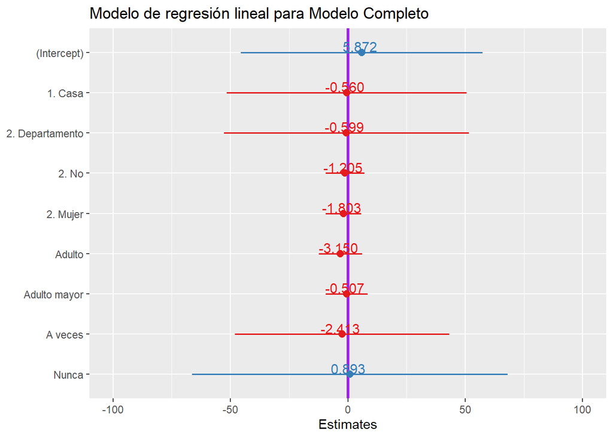

5.1 Gráfico para Modelo completo con diseño muestral

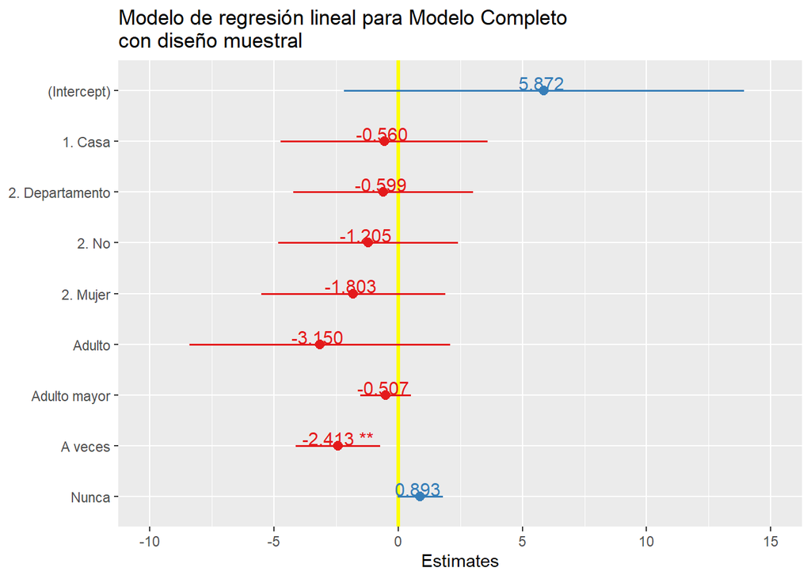

```r
plot_model(modelo_survey, type = c("est"),
  show.intercept = T,
  show.values = T,
  show.p = T,
  digits = 3,
  vline.color = "yellow",
  title = "Modelo de regresión lineal para Modelo Completo con diseño muestral")
```

En general los modelos no presentan mayores diferencias, sin embargo se puede afirmar que ambos entregan resultados insuficientes para afirmar y responder a nuestra pregunta de investigación inicial.

# Conclusiones

# Referencias

- Buitrago, F., Ciurana, R., Fernández, M., Tizón, J. (2021) Repercusiones de la pandemia de la COVID-19 en la salud mental de la población general. Reflexiones y propuestas. Elsevier España, Vol. 3, n°7. Recuperado de: https://www.sciencedirect.com/science/article/pii/S0212656721001773?via%3Dihub